# VLM Wrong Predictions: attr_structure_position [both_right]

Asset 47049 2 images

Predicted: VLM: At-Grade | DINOv3: At-Grade (conf: N/A)

Actual: At-Grade

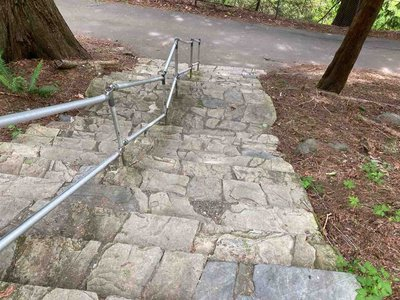

43882__AST_EX_20220601_110955.jpeg

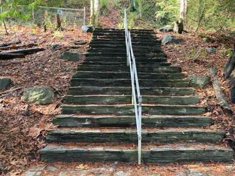

75505__AST_EX_20241022_111626.jpeg

Asset 47050 1 image

Predicted: VLM: At-Grade | DINOv3: At-Grade (conf: N/A)

Actual: At-Grade

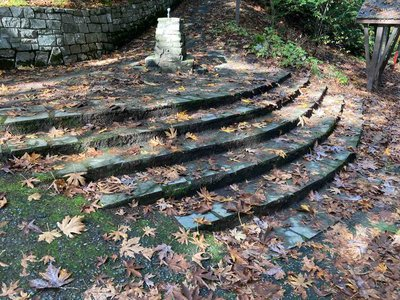

75503__AST_EX_20241022_112733.jpeg

Asset 47053 2 images

Predicted: VLM: At-Grade | DINOv3: At-Grade (conf: N/A)

Actual: At-Grade

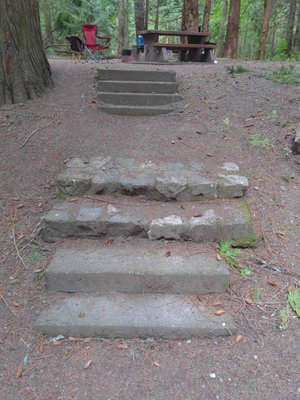

43873__MI_20220601_102208.jpg

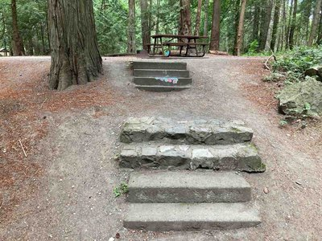

71435__AST_EX_20240725_113728.jpeg

Asset 47054 2 images

Predicted: VLM: At-Grade | DINOv3: At-Grade (conf: N/A)

Actual: At-Grade

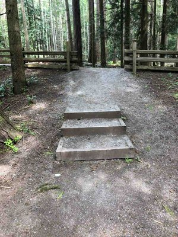

43914__AST_EX_20220601_104524.jpeg

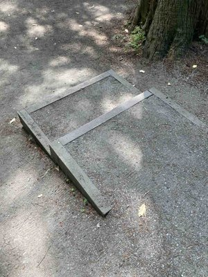

71343__AST_EX_20240725_135329.jpeg

Asset 47184 1 image

Predicted: VLM: Elevated | DINOv3: Elevated (conf: N/A)

Actual: Elevated

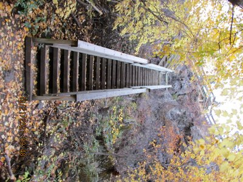

34371__IMG_8323.JPG

Asset 48269 1 image

Predicted: VLM: At-Grade | DINOv3: At-Grade (conf: N/A)

Actual: At-Grade

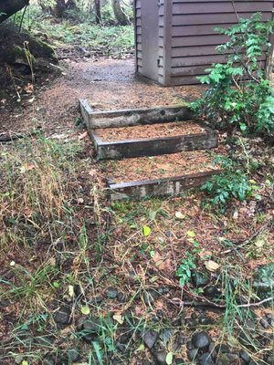

21402__AST_EX_20210911_135039.jpeg

Asset 48347 1 image

Predicted: VLM: At-Grade | DINOv3: At-Grade (conf: N/A)

Actual: At-Grade

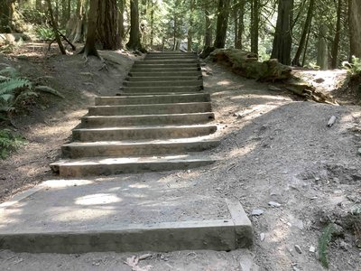

10724__AST_EX_20210805_145415.jpeg

Asset 48394 1 image

Predicted: VLM: At-Grade | DINOv3: At-Grade (conf: N/A)

Actual: At-Grade

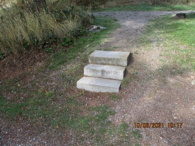

29363__IMG_7169.JPG

Asset 48395 1 image

Predicted: VLM: At-Grade | DINOv3: At-Grade (conf: N/A)

Actual: At-Grade

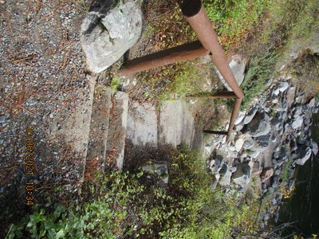

30801__IMG_7257.JPG

Asset 48799 1 image

Predicted: VLM: At-Grade | DINOv3: At-Grade (conf: N/A)

Actual: At-Grade

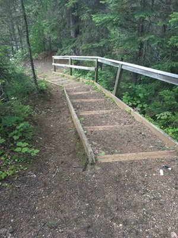

48667__AST_EX_20220622_154539.jpeg

Asset 48937 1 image

Predicted: VLM: At-Grade | DINOv3: At-Grade (conf: N/A)

Actual: At-Grade

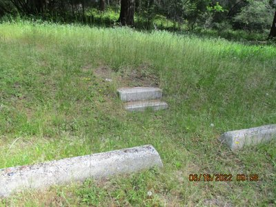

47772__IMG_6936.JPG

Asset 49501 1 image

Predicted: VLM: At-Grade | DINOv3: At-Grade (conf: N/A)

Actual: At-Grade

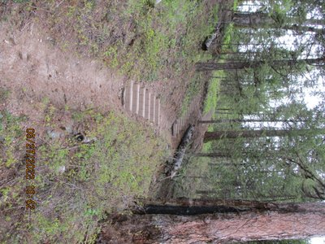

49517__IMG_5813.JPG

Asset 49525 1 image

Predicted: VLM: Elevated | DINOv3: Elevated (conf: N/A)

Actual: Elevated

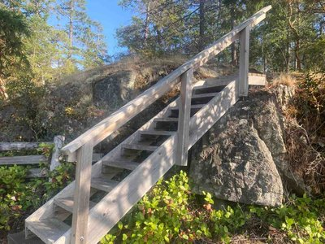

60995__AST_EX_20220823_170814.jpeg

Asset 49704 1 image

Predicted: VLM: At-Grade | DINOv3: At-Grade (conf: N/A)

Actual: At-Grade

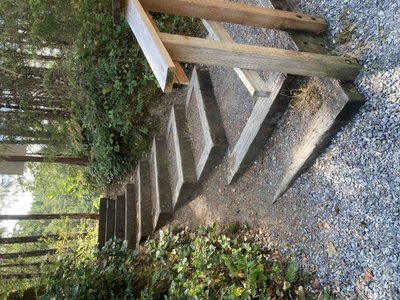

12171__AST_EX_20210809_143406.jpeg

Asset 49710 2 images

Predicted: VLM: At-Grade | DINOv3: At-Grade (conf: N/A)

Actual: At-Grade

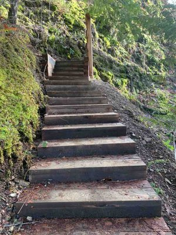

35827__AST_EX_20220211_105001.jpeg

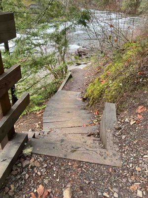

78022__AST_EX_20241210_120122.jpeg

Asset 49711 7 images

Predicted: VLM: At-Grade | DINOv3: At-Grade (conf: N/A)

Actual: At-Grade

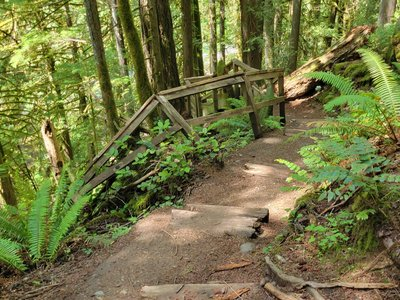

52730__MI_20220707_140301.jpg

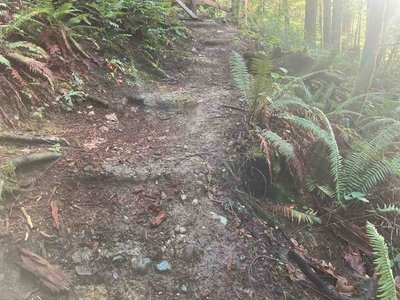

78137__AST_EX_20241218_121758.jpeg

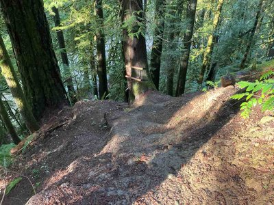

78152__AST_EX_20241218_121742.jpeg

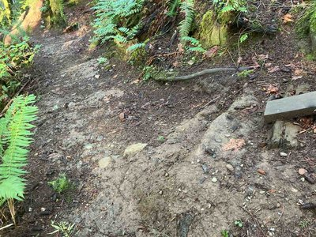

78160__AST_EX_20241218_121723.jpeg

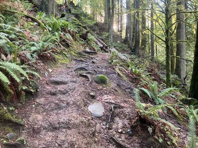

78164__AST_EX_20241218_122015.jpeg

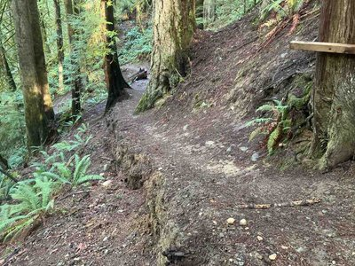

78165__AST_EX_20241218_121823.jpeg

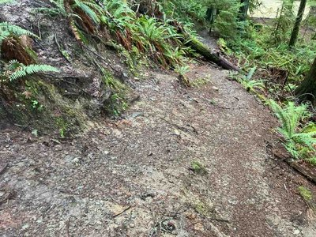

78166__AST_EX_20241218_122024.jpeg

Asset 50514 1 image

Predicted: VLM: At-Grade | DINOv3: At-Grade (conf: N/A)

Actual: At-Grade

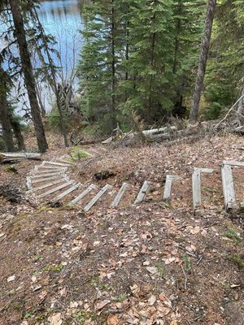

42055__AST_EX_20220511_125800.jpeg

Asset 50805 1 image

Predicted: VLM: At-Grade | DINOv3: At-Grade (conf: N/A)

Actual: At-Grade

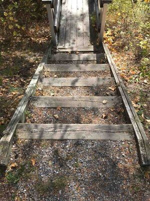

25286__AST_EX_20211002_121048.jpeg

Asset 51270 1 image

Predicted: VLM: Elevated | DINOv3: Elevated (conf: N/A)

Actual: Elevated

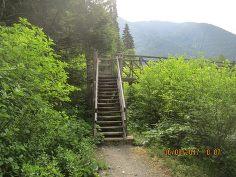

52700__IMG_9104.JPG

Asset 51458 2 images

Predicted: VLM: At-Grade | DINOv3: At-Grade (conf: N/A)

Actual: At-Grade

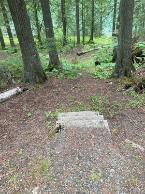

83334__AST_EX_20250606_152956.jpeg

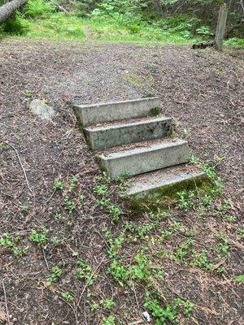

83339__AST_EX_20250606_152945.jpeg

Asset 51536 1 image

Predicted: VLM: At-Grade | DINOv3: At-Grade (conf: N/A)

Actual: At-Grade

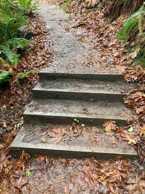

77015__AST_EX_20241106_114709.jpeg

Asset 51537 4 images

Predicted: VLM: Elevated | DINOv3: Elevated (conf: N/A)

Actual: Elevated

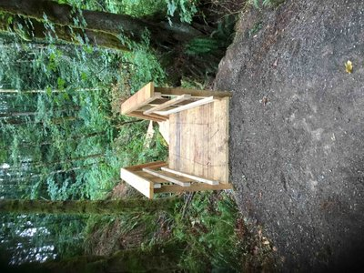

77900__AST_EX_20210826_112045_1_.jpeg

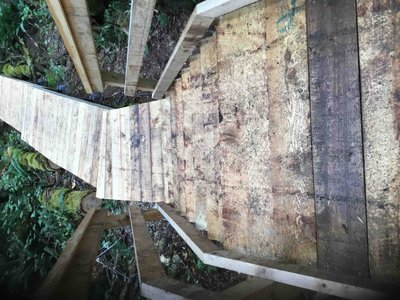

77901__AST_EX_20210826_112118_1_.jpeg

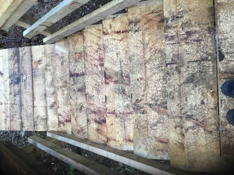

77902__AST_EX_20210826_112202_1_.jpeg

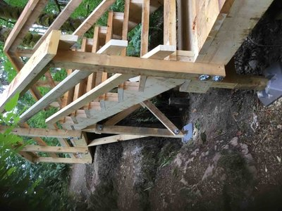

77903__AST_EX_20210826_113218_1_.jpeg

Asset 51804 3 images

Predicted: VLM: At-Grade | DINOv3: At-Grade (conf: N/A)

Actual: At-Grade

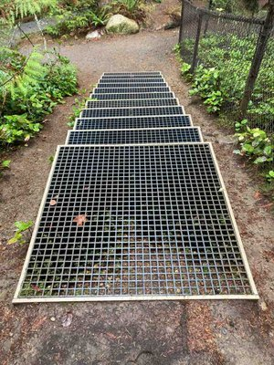

30765__AST_EX_20211103_152256.jpeg

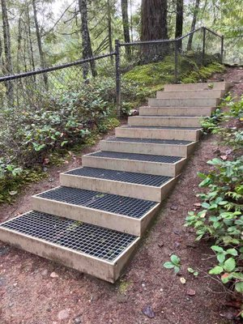

77876__AST_EX_20241128_121633.jpeg

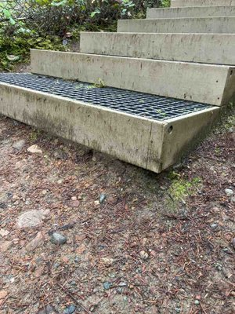

77877__AST_EX_20241128_121641.jpeg

Asset 52162 1 image

Predicted: VLM: At-Grade | DINOv3: At-Grade (conf: N/A)

Actual: At-Grade

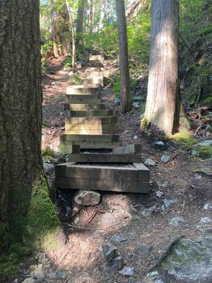

58220__AST_EX_20220807_100025.jpeg

Asset 52248 3 images

Predicted: VLM: Elevated | DINOv3: Elevated (conf: N/A)

Actual: Elevated

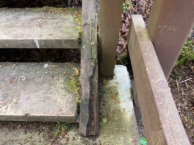

40567__AST_EX_20220510_114016.jpeg

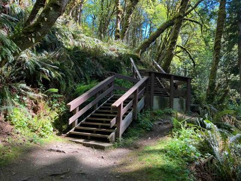

40586__AST_EX_20220510_113813.jpeg

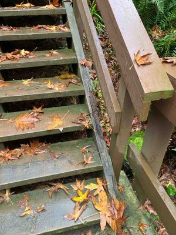

75267__AST_EX_20241016_132736.jpeg

Asset 52622 1 image

Predicted: VLM: At-Grade | DINOv3: At-Grade (conf: N/A)

Actual: At-Grade

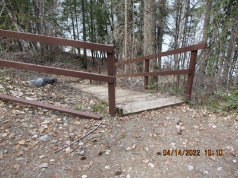

53754__IMG_3324.JPG

Asset 52952 1 image

Predicted: VLM: Elevated | DINOv3: Elevated (conf: N/A)

Actual: Elevated

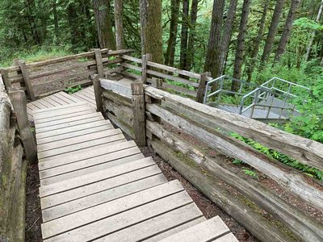

50107__AST_EX_20220628_130004.jpeg

Asset 53110 1 image

Predicted: VLM: At-Grade | DINOv3: At-Grade (conf: N/A)

Actual: At-Grade

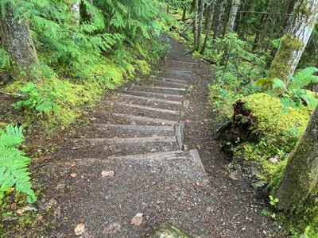

45603__AST_EX_20220609_114340.jpeg

Asset 53111 1 image

Predicted: VLM: At-Grade | DINOv3: At-Grade (conf: N/A)

Actual: At-Grade

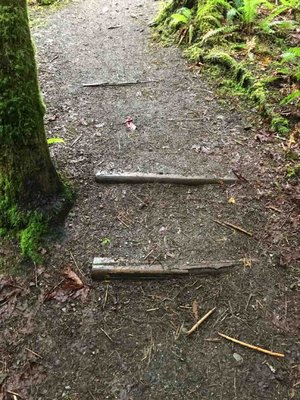

45616__AST_EX_20220609_114149.jpeg

Asset 53212 3 images

Predicted: VLM: At-Grade | DINOv3: At-Grade (conf: N/A)

Actual: At-Grade

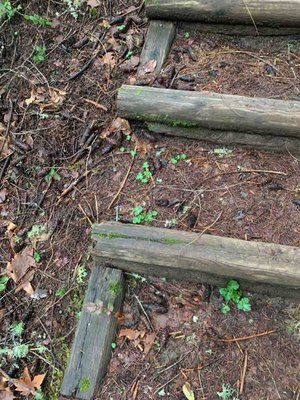

35514__AST_EX_20220121_144709.jpeg

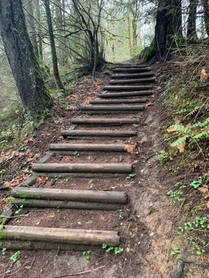

35516__AST_EX_20220121_144646.jpeg

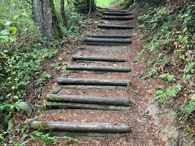

71833__AST_EX_20240730_132053.jpeg

Asset 53214 2 images

Predicted: VLM: At-Grade | DINOv3: At-Grade (conf: N/A)

Actual: At-Grade

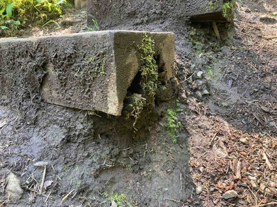

43209__AST_EX_20220527_125704.jpeg

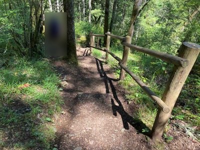

43212__AST_EX_20220527_125526.jpeg

Asset 53221 2 images

Predicted: VLM: At-Grade | DINOv3: At-Grade (conf: N/A)

Actual: At-Grade

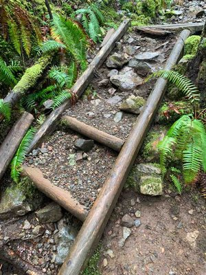

37284__AST_EX_20220323_120008.jpeg

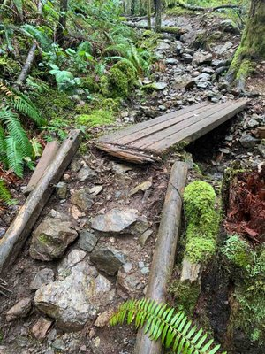

37300__AST_EX_20220323_120017.jpeg

Asset 53222 2 images

Predicted: VLM: At-Grade | DINOv3: At-Grade (conf: N/A)

Actual: At-Grade

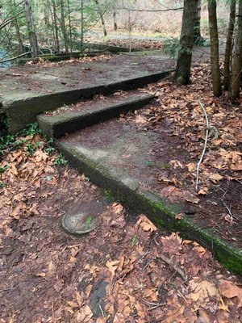

35518__AST_EX_20220121_143710.jpeg

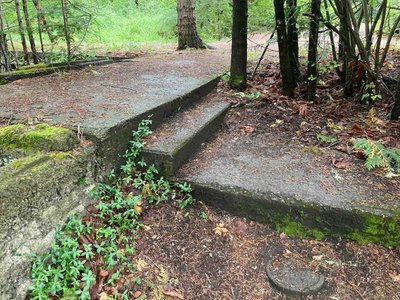

71819__AST_EX_20240730_131510.jpeg

Asset 53428 1 image

Predicted: VLM: At-Grade | DINOv3: At-Grade (conf: N/A)

Actual: At-Grade

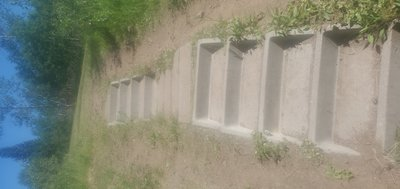

1706__MI_20210622_150104.jpg

Asset 53688 3 images

Predicted: VLM: At-Grade | DINOv3: At-Grade (conf: N/A)

Actual: At-Grade

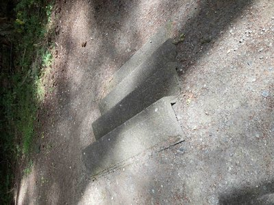

10714__AST_EX_20210805_122929.jpeg

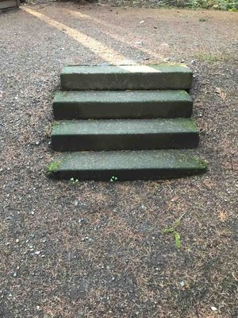

27672__AST_EX_20211018_165939.jpeg

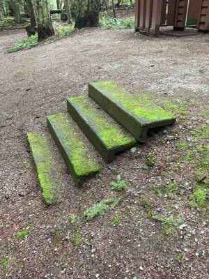

78271__AST_EX_20250107_132821.jpeg

Asset 53805 2 images

Predicted: VLM: At-Grade | DINOv3: At-Grade (conf: N/A)